# Cinci Spark Meetup

Eugene Pyatigorsky

15 March, 2017

This notebook is available on: https://github.com/epspi/02.28.2017_Cin-Day_RUG_sparklyr

The data is available at census.gov: https://www.census.gov/econ/cfs/pums.html

A fully instructive tutorial is at: http://spark.rstudio.com/

## Installation & Connection

`sparklyr` and `dplyr` is what we’ll be using. Install Spark directly from R with the handy `spark_install()` function within `sparklyr`

```r
if (!require(dplyr)) install.packages("dplyr")
if (!require(data.table)) install.packages("data.table")
if (!require(sparklyr)) install.packages("sparklyr")

library(dplyr)
library(data.table)
library(sparklyr)

# spark_install(version = "2.0.1")
# spark_install(version = "1.6.2")
```

You can connect to spark using the GUI or by calling `spark_connect` and specifying which version of Spark you want to use and whether you want a local or remote master. If you don’t specify a version, it will default to *version 1.6.2* (as of March 2017).

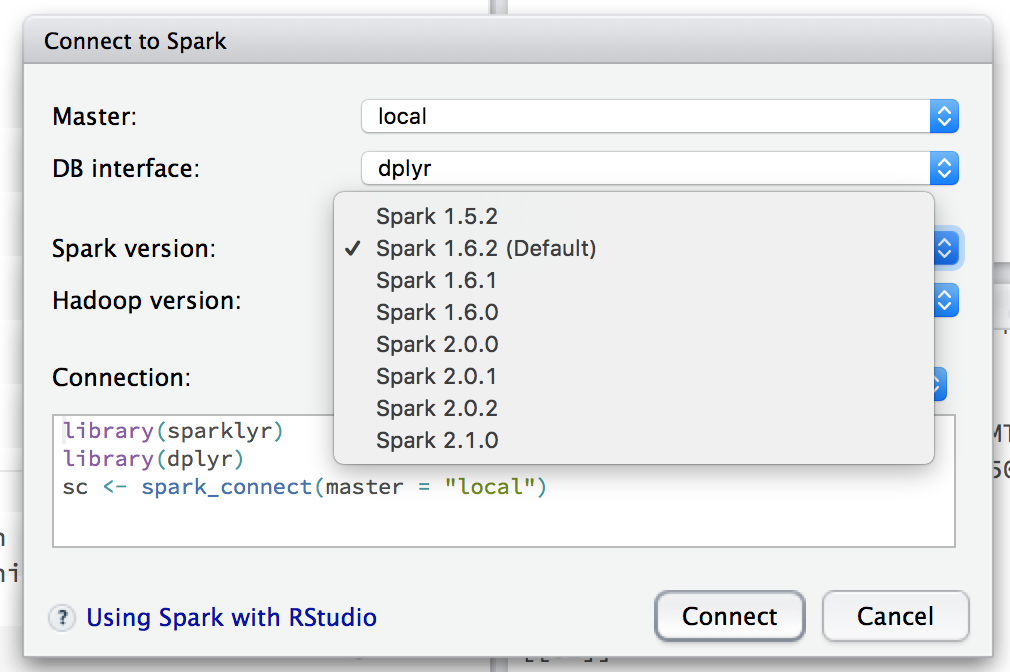

```r
sc <- spark_connect(master = "local", version = "2.0.1")
```

```
Re-using existing Spark connection to local
```

```r
# If you have port conflicts, try:
# config <- spark_config()
# config$sparklyr.gateway.port <-  5454
# sc <- spark_connect(master = "local", config = config)
sc
```

```
$master
[1] "local[4]"

$method
[1] "shell"

$app_name
[1] "sparklyr"

$config
$config$sparklyr.cores.local
[1] 4

$config$spark.sql.shuffle.partitions.local
[1] 4

$config$spark.env.SPARK_LOCAL_IP.local
[1] "127.0.0.1"

$config$sparklyr.csv.embedded
[1] "^1.*"

$config$`sparklyr.shell.driver-class-path`
[1] ""

attr(,"config")
[1] "default"
attr(,"file")
[1] "/Library/Frameworks/R.framework/Versions/3.3/Resources/library/sparklyr/conf/config-template.yml"

$spark_home
[1] "/Users/eugene/Library/Caches/spark/spark-2.0.1-bin-hadoop2.7"

$backend
        description               class                mode
"->localhost:51435"          "sockconn"                "wb"
               text              opened            can read
           "binary"            "opened"               "yes"
          can write
              "yes"
```

[output cut: 15 more lines]

```
  org.apache.spark.SparkContext@148a41fa

$java_context
<jobj[6]>
  class org.apache.spark.api.java.JavaSparkContext
  org.apache.spark.api.java.JavaSparkContext@757b1461

$hive_context
<jobj[9]>
  class org.apache.spark.sql.SparkSession
  org.apache.spark.sql.SparkSession@12b8290a

attr(,"class")
[1] "spark_connection"       "spark_shell_connection"
[3] "DBIConnection"
```

```r
# List of RDDs currently in the cluster
src_tbls(sc)
```

```
[1] "ship2"
```

```r
# Web utility
spark_web(sc)
```

```
Spark UI URL not found in logs, attempting to guess.
```

## Importing Data

We need to feed data into the Spark cluster, whether by copying it from R objects or by using one of the filereader functions.

```r
    ship <- fread("data/cfs_2012_pumf_csv.txt")
```

```
Read 4.0% of 4547661 rows
Read 29.9% of 4547661 rows
Read 57.6% of 4547661 rows
Read 82.9% of 4547661 rows
Read 4547661 rows and 20 (of 20) columns from 0.350 GB file in 00:00:06
```

There are (at least) three readers for getting data *directly* into the cluster:

- `spark_read_csv`
- `spark_read_parquet`
- `spark_read_json`

#### spark_read_csv

```r
system.time(
    ship2_sp <- spark_read_csv(sc, "ship2",
                           "data/cfs_2012_pumf_csv.txt")
)
```

```
   user  system elapsed
  0.083   0.063  30.084
```

We can’t use `names` to figure out what’s in the spark tables, but `colnames` and `tbl_vars` work

```r
tbl_vars(ship2_sp)
```

```
 [1] "SHIPMT_ID"          "ORIG_STATE"         "ORIG_MA"
 [4] "ORIG_CFS_AREA"      "DEST_STATE"         "DEST_MA"
 [7] "DEST_CFS_AREA"      "NAICS"              "QUARTER"
[10] "SCTG"               "MODE"               "SHIPMT_VALUE"
[13] "SHIPMT_WGHT"        "SHIPMT_DIST_GC"     "SHIPMT_DIST_ROUTED"
[16] "TEMP_CNTL_YN"       "EXPORT_YN"          "EXPORT_CNTRY"
[19] "HAZMAT"             "WGT_FACTOR"
```

The RStudio table viewer also works on Spark tables

```r
head(ship2_sp) %>% View
```

## Manipulating Data with dplyr

You can use **some** (all?) of the dplyr verbs and also SQL commands directly on spark tables. That’s basically the whole point.

```r
ship2_sp %>% count(ORIG_STATE)
```

| ORIG_STATE | n |
| --- | --- |
| 19 | 75307 |
| 55 | 137727 |
| 39 | 221321 |
| 31 | 57500 |
| 27 | 127000 |
| 47 | 119696 |
| 51 | 109397 |
| 23 | 26783 |
| 35 | 22738 |
| 15 | 28796 |

[output cut: 42 more lines]

Spark will defer calculation until you deliberately or implictely try to `collect` the data back as an R object.

```r
head(ship2_sp)
```

| SHIPMT_ID | ORIG_STATE | ORIG_MA | ORIG_CFS_AREA | DEST_STATE | DEST_MA | DEST_CFS_AREA | NAICS | QUARTER | SCTG | MODE | SHIPMT_VALUE | SHIPMT_WGHT | SHIPMT_DIST_GC | SHIPMT_DIST_ROUTED | TEMP_CNTL_YN | EXPORT_YN | EXPORT_CNTRY | HAZMAT | WGT_FACTOR |
| --- | --- | --- | --- | --- | --- | --- | --- | --- | --- | --- | --- | --- | --- | --- | --- | --- | --- | --- | --- |
| 1 | 25 | 148 | 25-148 | 25 | 148 | 25-148 | 333 | 2 | 35 | 14 | 2178 | 11 | 14 | 17 | N | N | N | N | 208.5 |
| 2 | 42 | 428 | 42-428 | 6 | 41740 | 06-41740 | 311 | 3 | 35 | 14 | 344 | 11 | 2344 | 2734 | N | N | N | N | 193.3 |
| 3 | 26 | 220 | 26-220 | 47 | 314 | 47-314 | 322 | 2 | 27 | 4 | 4197 | 5134 | 470 | 579 | N | N | N | N | 51.2 |
| 4 | 20 | 556 | 20-556 | 20 | 556 | 20-556 | 323 | 1 | 29 | 4 | 116 | 6 | 3 | 3 | N | N | N | N | 238.7 |
| 5 | 12 | 99999 | 12-99999 | 12 | 99999 | 12-99999 | 4235 | 3 | 33 | 5 | 388 | 527 | 124 | 201 | N | N | N | N | 398.1 |
| 6 | 24 | 47900 | 24-47900 | 30 | 99999 | 30-99999 | 337 | 2 | 40 | 4 | 3716 | 1132 | 1942 | 2265 | N | Y | C | N | 21.9 |

```r
spark_log(sc, n = 3)
```

```
17/03/15 20:49:45 INFO DAGScheduler: ResultStage 39 (collect at utils.scala:195) finished in 0.007 s
17/03/15 20:49:45 INFO TaskSchedulerImpl: Removed TaskSet 39.0, whose tasks have all completed, from pool
17/03/15 20:49:45 INFO DAGScheduler: Job 23 finished: collect at utils.scala:195, took 0.012702 s
```

For example, we select some columns of interest and assign the resulting df to a new variables. However, as we see by calling `names` or `str` on the resulting variable, it’s still a spark object, not a **collected** df.

```r
ship_values <- ship2_sp %>%
    select(contains("SHIPMT"))
names(ship_values)
```

```
[1] "src" "ops"
```

Once we ask for the contents of `ship_values`, however, an implicit collection occurs

```r
ship_values %>% head
```

| SHIPMT_ID | SHIPMT_VALUE | SHIPMT_WGHT | SHIPMT_DIST_GC | SHIPMT_DIST_ROUTED |
| --- | --- | --- | --- | --- |
| 1 | 2178 | 11 | 14 | 17 |
| 2 | 344 | 11 | 2344 | 2734 |
| 3 | 4197 | 5134 | 470 | 579 |
| 4 | 116 | 6 | 3 | 3 |
| 5 | 388 | 527 | 124 | 201 |
| 6 | 3716 | 1132 | 1942 | 2265 |

## Machine Learning

The `sparklyr` API includes interfaces to way more `Spark ML` facilities than the previous API from Spark directly.

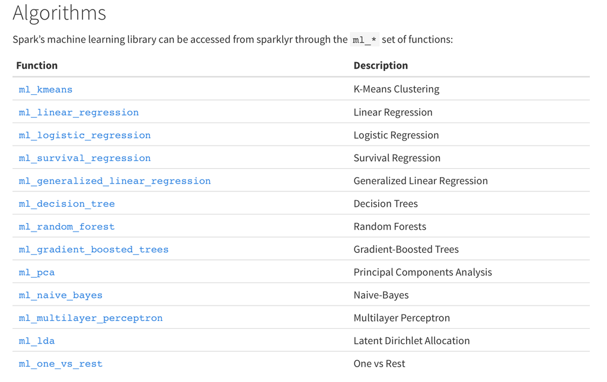

### Regression Example

Let’s try running a simple linear regression of shipment values of some other numeric variables

```r
system.time({
    lm_sp <- ship_values %>%
    select(-SHIPMT_ID) %>%
    ml_linear_regression(SHIPMT_VALUE ~ .)
})
```

[output not shown]

```r
system.time({
    dat <- ship %>%
    select(contains("SHIPMT")) %>%
    select(-SHIPMT_ID)

lm_R <- lm(SHIPMT_VALUE ~ ., data = dat)
})
```

[output not shown]

The output of the Spark linear regression is an object of a different type than the usual `lm` class.

```r
class(lm_sp)
class(lm_R)
```

[output not shown]

```r
cat("\nSpark LM Summary Output\n")
summary(lm_sp)

cat("\n\nR LM Summary Output\n")
summary(lm_R)
```

[output not shown]

The Spark machine learning output object has basically all the same values as the equivalent R object

```r
names(lm_sp)
```

[output not shown]

One difference is that the Spark output does not contain the original data (for good reason!), which means that there is no `plot` method defined on the object.

```r
# DOES NOT WORK!
#plot(lm_sp)

# Works but may crash anyways due to size
#plot(lm_R)
```

## More Involved Regression Example

Let’s split the dataset according to origin state (`ORIG_STATE`) and fit a linear model to each subset.

### Regular R

```r
system.time({
    stateModelsR <- ship %>%
        select(ORIG_STATE, contains("SHIPMT"), -SHIPMT_ID) %>%
        by(., .$ORIG_STATE, . %>% {
            lm(SHIPMT_VALUE ~ . - ORIG_STATE, data = .)
        })
})
```

```
   user  system elapsed
 10.817   1.486  12.503
```

```r
stateModelsR
```

```
.$ORIG_STATE: 0

Call:
lm(formula = SHIPMT_VALUE ~ . - ORIG_STATE, data = .)

Coefficients:
       (Intercept)         SHIPMT_WGHT      SHIPMT_DIST_GC
         3455.4317              0.2394              8.9563
SHIPMT_DIST_ROUTED
           -4.0085

--------------------------------------------------
.$ORIG_STATE: 1

Call:
lm(formula = SHIPMT_VALUE ~ . - ORIG_STATE, data = .)

Coefficients:
       (Intercept)         SHIPMT_WGHT      SHIPMT_DIST_GC
        8560.56310             0.08376           -63.52657
SHIPMT_DIST_ROUTED
          60.38119

--------------------------------------------------
.$ORIG_STATE: 2

Call:
lm(formula = SHIPMT_VALUE ~ . - ORIG_STATE, data = .)

Coefficients:
       (Intercept)         SHIPMT_WGHT      SHIPMT_DIST_GC
         2650.4143              0.1865             26.8534
SHIPMT_DIST_ROUTED
           -2.2437

--------------------------------------------------
.$ORIG_STATE: 4

Call:
lm(formula = SHIPMT_VALUE ~ . - ORIG_STATE, data = .)
```

[output cut: 567 more lines]

```
         7221.8083              0.1851            -19.0403
SHIPMT_DIST_ROUTED
           18.4786

--------------------------------------------------
.$ORIG_STATE: 56

Call:
lm(formula = SHIPMT_VALUE ~ . - ORIG_STATE, data = .)

Coefficients:
       (Intercept)         SHIPMT_WGHT      SHIPMT_DIST_GC
         7.200e+03           7.722e-03          -2.225e+00
SHIPMT_DIST_ROUTED
        -2.326e-01
```

### Spark

First, we cache the spark RDD

```r
# Cache Spark table to memory (may already be cached after
# spark_read_csv)
tbl_cache(sc, "ship2")
```

Replicating the form we used above won’t work for Spark, because `by` doesn’t work. Trust me, it will break the backend and you’ll have to restart. The next candidate is `group_by` with `do`, made available in Jan 2017 with the release of *sparklyr 0.5*. https://blog.rstudio.org/2017/01/24/sparklyr-0-5/

```r
system.time({
    stateModelsSp <- ship2_sp %>%
        select(ORIG_STATE, contains("SHIPMT"), -SHIPMT_ID) %>%
        group_by(ORIG_STATE) %>%
        do(mod = ml_linear_regression(
            SHIPMT_VALUE ~ . - ORIG_STATE, data = .)
        )
})
```

[output not shown]

```
   user  system elapsed
  5.540   0.655 122.815
```

The resulting object is a data frame with a column identifying our origin states and a second column containing a pointer to the actual models

| ORIG_STATE | mod |
| --- | --- |
| 25 |  |
| 12 |  |
| 13 |  |
| 37 |  |
| 18 |  |
| 38 |  |
| 56 |  |
| 46 |  |
| 50 |  |
| 42 |  |

[output cut: 42 more lines]

```r
stateModelsSp$mod
```

```
[[1]]
Call: ml_linear_regression(SHIPMT_VALUE ~ . - ORIG_STATE, data = .)

Coefficients:
       (Intercept)        SHIPMT_WGHT     SHIPMT_DIST_GC
      5872.3073921          0.1804177        -18.6931882
SHIPMT_DIST_ROUTED
        18.9507978


[[2]]
Call: ml_linear_regression(SHIPMT_VALUE ~ . - ORIG_STATE, data = .)

Coefficients:
       (Intercept)        SHIPMT_WGHT     SHIPMT_DIST_GC
      6096.8444250          0.1404385         -7.6919987
SHIPMT_DIST_ROUTED
         8.6838328


[[3]]
Call: ml_linear_regression(SHIPMT_VALUE ~ . - ORIG_STATE, data = .)

Coefficients:
       (Intercept)        SHIPMT_WGHT     SHIPMT_DIST_GC
      1.561933e+04       3.584192e-02      -8.319105e+01
SHIPMT_DIST_ROUTED
      7.088335e+01


[[4]]
Call: ml_linear_regression(SHIPMT_VALUE ~ . - ORIG_STATE, data = .)

Coefficients:
       (Intercept)        SHIPMT_WGHT     SHIPMT_DIST_GC
      11882.942807           0.323768         -50.336016
SHIPMT_DIST_ROUTED
         48.751548


```

[output cut: 463 more lines]

```
Coefficients:
       (Intercept)        SHIPMT_WGHT     SHIPMT_DIST_GC
     1577.98473773         0.05000637         1.01444753
SHIPMT_DIST_ROUTED
       -1.27424769


[[52]]
Call: ml_linear_regression(SHIPMT_VALUE ~ . - ORIG_STATE, data = .)

Coefficients:
       (Intercept)        SHIPMT_WGHT     SHIPMT_DIST_GC
      3455.4317298          0.2393913          8.9562576
SHIPMT_DIST_ROUTED
        -4.0085214
```